# 1. Overlaying treatment polygons with Treemap

Author

Carmen Tubbesing

Published

November 5, 2025

# User Inputs - Change these each project

*These are the things you have to edit between projects*

### Define the name and ID number of the project

```r
proj_name <- "Example Project"
```

```r
project_ID <- "8EX25605"
```

### Define impact area buffer distance, in meters

```r
buffer_dist <- 500
```

### Define which treatments are site prep, biomass utilization, or other treatment types that do not require FVS inputs.

List the TCNs of treatments not needing FVS input files

```r
noFVS <- c(1.2,1.5,1.6,2.2,2.3,3.2,3.5,3.6,4.1,4.2,4.3,5.1)
```

Note: Do not include reforestation treatments in `noFVS`. Even though FVS is not run on them, the FVS input files are used to determine species of regenerating conifers.

### Define which year of TreeMap you want to use

```r
tm <- 2022 # Options = 2016, 2020, 2022
```

## Define directory with treatment shapefiles in it

```r
trt_dir <- "~/CCI/QMs/Forest Health QM/Test runs/8EX25605/Shapefiles"
```

# This run is for project 8EX25605, AKA Example Project

# Files needed:

- TreeMap datasets, clipped to CA (.tif for each year)
- A directory with treatment shapefiles within it (can be in nested/zipped folders)
- The FVS variants and locations shapefile

# Setup

*These are the things you have to edit if it’s your first time using this script*

### Define directory with CA perimeter shapefile in it

```r
ca_dir <- "~/Reference data/CA boundary/ca-state-boundary"
```

### Define input and output dir

```r
input_dir <- "~/../../Data_heavy_projects/Forest_QM_automation/data/TreeMap"
output_dir <- "~/../../Data_heavy_projects/Forest_QM_automation/temp"
triaads_output_dir <- "~/../../Data_heavy_projects/Forest_QM_automation/triaads_input"
output_dir_randig <- "~/../../Data_heavy_projects/Forest_QM_automation/randig_shapefiles"
```

### Define FVS variant location shapefile

```r
fvs_varloc_shp_path <- file.path(input_dir, "../../FVS_files/FVSVariantMap20210525/FVS_Variants_and_Locations.shp")
fvs_varloc <- st_read(fvs_varloc_shp_path, quiet = T)
```

### Clear output directory (`temp`)

```r
unlink(paste0(output_dir, "/*"), recursive = TRUE)
```

### Read in TreeMap dataset(s)

```r
tm16file <- file.path(input_dir, "TreeMap2016/tm2016_ca/tm2016_ca.tif")
tm20file <- file.path(input_dir, "TreeMap2020/tm2020_ca/TM2020_CA.tif")
tm22file <- file.path(input_dir, "TreeMap2022/tm2022_ca.tif")
```

```r
if(tm == 2016){
  tm16 <- rast(tm16file)
  names(tm16) <- "TM_ID"
  tmrast <- tm16
} else if(tm == 2020){
  tm20 <- rast(tm20file)
  tmrast <- tm20
} else if(tm == 2022){
  tm22 <- rast(tm22file)
  tmrast <- tm22
} else{
  print("ERROR: Not a valid TreeMap year")
}
```

## If necessary, unzip treatment shapefiles

```r
# List all zipped files in the Shapefiles folder
zip_files <- list.files(trt_dir, pattern = "\\.zip$", full.names = TRUE)

# Loop through each zipped file and extract its contents
for (zip_file in zip_files) {
  unzip(zip_file, exdir = trt_dir)
}

print("All zipped files have been extracted.")
```

```
[1] "All zipped files have been extracted."
```

## List shapefiles in `trt_dir`, ignoring those with “buffer” or “boundary” in the name

```r
shapefiles <- list.files(
  path = trt_dir,
  pattern = "\\.shp$",
  full.names = TRUE,
  recursive = TRUE
)

shapefiles <- shapefiles[!grepl("buffer", shapefiles)]
shapefiles <- shapefiles[!grepl("Boundary", shapefiles)]
shapefiles <- shapefiles[!grepl("boundary", shapefiles)]
basename(shapefiles)
```

```
 [1] "71399131_1_1_20250110_region.shp" "71399131_1_2_20250110_region.shp"
 [3] "71399131_1_3_20250110_region.shp" "71399131_1_4_20250110_region.shp"
 [5] "71399131_1_5_20250110_region.shp" "71399131_1_6_20250110_region.shp"
 [7] "71399131_2_1_20250110_region.shp" "71399131_2_2_20250110_region.shp"
 [9] "71399131_2_3_20250110_region.shp" "71399131_3_1_20250110_region.shp"
[11] "71399131_3_2_20250110_region.shp" "71399131_3_3_20250110_region.shp"
[13] "71399131_3_4_20250110_region.shp" "71399131_3_5_20250110_region.shp"
[15] "71399131_3_6_20250110_region.shp" "71399131_4_1_20250110_region.shp"
[17] "71399131_4_2_20250110_region.shp" "71399131_4_3_20250110_region.shp"
[19] "71399131_5_1_20250110_region.shp" "71399131_6_1_20250110_region.shp"
[21] "71399131_6_2_20250110_region.shp" "71399131_6_3_20250110_region.shp"
[23] "71399131_6_4_20250110_region.shp" "71399131_6_5_20250110_region.shp"
[25] "71399131_6_6_20250110_region.shp" "71399131_7_1_20250110_region.shp"
[27] "71399131_8_1_20250110_region.shp" "71399131_8_2_20250110_region.shp"
[29] "71399131_8_3_20250110_region.shp" "71399131_8_4_20250110_region.shp"
[31] "71399131_9_1_20250110_region.shp" "71399131_9_2_20250110_region.shp"
[33] "71399131_9_3_20250110_region.shp"
```

## Create shp_list

```r
shp_list <- list()
for(i in 1:length(shapefiles)){
  shp <- st_read(shapefiles[i], quiet= T) %>% st_zm()
  shp_list[[i]] <- shp
}
```

```r
print(paste("There are", length(shapefiles), "shapefiles and", length(shp_list), "polygon features, each saved in `shp_list`"))
```

```
[1] "There are 33 shapefiles and 33 polygon features, each saved in `shp_list`"
```

# Prepare shapefiles & TreeMap raster for spatial overlay

### Make sure that each shapefile has TCN variable and rename if necessary

```r
# Define possible names for the TCN column
tcn_variants <- c("Tcn", "TreatmentC", "tcn", "treatmentc", "TNumber")

# Function to rename the TCN column in a single sf object
rename_tcn_column <- function(sf_obj) {
  current_names <- names(sf_obj)
  match_name <- current_names[current_names %in% tcn_variants]
  if (length(match_name) == 1) {
    names(sf_obj)[names(sf_obj) == match_name] <- "TCN"
  }
  return(sf_obj)
}

# Apply the function to each element in the list
shp_list <- lapply(shp_list, rename_tcn_column)
```

### Rename objective column

```r
# Define possible names for the TCN column
Tobj_variants <- c("Tobj", "TreatmentO", "TObj", "TObjective", "Tobjective")

# Function to rename the TCN column in a single sf object
rename_Tobj_column <- function(sf_obj) {
  current_names <- names(sf_obj)
  match_name <- current_names[current_names %in% Tobj_variants]
  if (length(match_name) == 1) {
    names(sf_obj)[names(sf_obj) == match_name] <- "Tobj"
  }
  return(sf_obj)
}

# Apply the function to each element in the list
shp_list <- lapply(shp_list, rename_Tobj_column)
```

### Rename Activity column

```r
# Define possible names for the TCN column
Tobj_variants <- c("TActivity")

# Function to rename the TCN column in a single sf object
rename_Tobj_column <- function(sf_obj) {
  current_names <- names(sf_obj)
  match_name <- current_names[current_names %in% Tobj_variants]
  if (length(match_name) == 1) {
    names(sf_obj)[names(sf_obj) == match_name] <- "Tactivity"
  }
  return(sf_obj)
}

# Apply the function to each element in the list
shp_list <- lapply(shp_list, rename_Tobj_column)
```

# Overlap treatments and FVS variants

### Prep `fvs_varloc`

```r
fvs_varloc <- vect(fvs_varloc)
fvs_varloc <- makeValid(fvs_varloc)
fvs_varloc <- project(fvs_varloc, crs(tmrast))
fvs_sf <- st_as_sf(fvs_varloc)
```

### Reproject each shp to match `fvs_sf`

```r
for(i in 1:length(shp_list)){
  shp_list[[i]] <- st_transform(shp_list[[i]], st_crs(fvs_sf))
}
```

### Add FVS variant column to each shapefile

```r
# Function to intersect and assign dominant FVSVariant
assign_fvsvariant <- function(shp) {
  # Intersect with fvs_sf
  intersection <- st_intersection(shp, fvs_sf)

  # Calculate area of each intersected piece
  intersection$area <- st_area(intersection)

  # Summarize area by FVSVariant for each original polygon
  dominant_variant <- intersection %>%
    arrange(desc(area)) %>%
    slice_max(area, n = 1) %>%
    select(FVSVariant) %>%
    st_drop_geometry() %>%
    unlist()

  # Join back to original shp
  shp$FVSVariant <- dominant_variant
  return(shp)
}
```

```r
shp_list <- lapply(shp_list, assign_fvsvariant)
```

# Add TCN if there is none or if it’s 0. Add “new” to the new TCNs to designate that I assigned them

```r
for(i in 1:length(shp_list)){
  shp_i <- shp_list[[i]]
  names <- names(shp_i)
  if(!"TCN" %in% names){
    print("CREATING TCNs!")
    shp_list[[i]]$TCN <- paste0(i, "new")
    print(shp_list[[i]]$TCN)
  }else{
    shp_list[[i]]$TCN <- as.character(shp_list[[i]]$TCN)
  }
  if(any(shp_i$TCN==0)|any(is.na(shp_i$TCN))){
    print("CREATING TCNs!")
    shp_list[[i]]$TCN <- paste0(i, "new")
    print(shp_list[[i]]$TCN %>% unique)
  }
}
```

# List treatment types

```r
for(i in 1:length(shp_list)){
  print(paste(unique(shp_list[[i]]$TCN), "is", shp_list[[i]]$Tobj %>% unique()))
}
```

```
[1] "1.1 is Fuels Reduction"
[1] "1.2 is Fuels Reduction"
[1] "1.3 is Fuels Reduction"
[1] "1.4 is Fuels Reduction"
[1] "1.5 is Fuels Reduction"
[1] "1.6 is Fuels Reduction"
[1] "2.1 is Fuels Reduction"
[1] "2.2 is Fuels Reduction"
[1] "2.3 is Fuels Reduction"
[1] "3.1 is Fuels Reduction"
[1] "3.2 is Fuels Reduction"
[1] "3.3 is Fuels Reduction"
[1] "3.4 is Fuels Reduction"
[1] "3.5 is Fuels Reduction"
[1] "3.6 is Fuels Reduction"
```

[output cut: 18 more lines]

# Combine all shapefiles for mapping

```r
combined_shp <- shp_list |> bind_rows()

# Ensure valid geometries
combined_shp <- st_make_valid(combined_shp %>% st_zm)
```

```r
combined_shp <- combined_shp %>%
  mutate(area = st_area(geometry)) %>%
  arrange(desc(area))  # Largest first
```

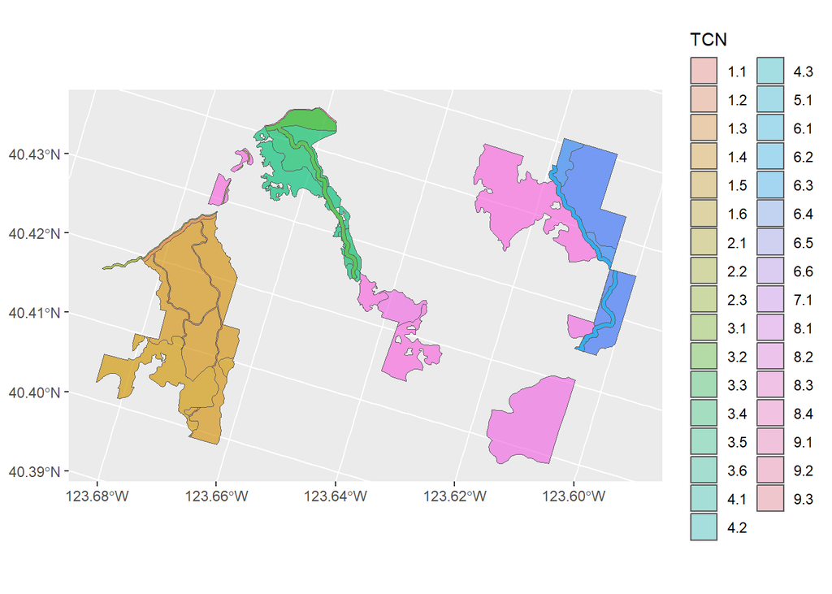

```r
ggplot(combined_shp)+
  geom_sf(aes(fill = TCN), alpha = .3)
```

# Impact Area calculations

*For projects that do not include Fuels Reduction or Pest Management, this section can be removed.*

### Create buffer polygons around each treatment and mask out the treatment area

```r
buffers <- list()
for (i in 1:length(shp_list)) {
  shp_sf <- shp_list[[i]]
  shp_sf$trt_area <- st_area(shp_sf)
  shp <- vect(shp_sf)
  base_name <- tools::file_path_sans_ext(basename(shapefiles[i]))

  if(!is.null("noFVS") & unique(shp_sf$TCN) %in% noFVS){
    print(paste("Skipping TCN =", shp_sf$TCN))
    next
  }

  shp_buff <- buffer(shp, width = buffer_dist)
  shp_buff <- aggregate(
    shp_buff,
    by = c("FVSVariant", "TCN"),
    fun = function(x) x[1]
  )

  shp_buff <- erase(shp_buff, shp)

  shp_buff_sf <- st_as_sf(shp_buff)
  shp_buff_sf$trt_area <- as.numeric(shp_buff_sf$trt_area)
  buffers[[base_name]] <- shp_buff_sf
}
```

```
[1] "Skipping TCN = 1.2"
[1] "Skipping TCN = 1.5"
[1] "Skipping TCN = 1.6"
[1] "Skipping TCN = 2.2"
[1] "Skipping TCN = 2.3"
[1] "Skipping TCN = 3.2"
[1] "Skipping TCN = 3.5"
[1] "Skipping TCN = 3.6"
[1] "Skipping TCN = 4.1"
[1] "Skipping TCN = 4.2"
[1] "Skipping TCN = 4.3"
[1] "Skipping TCN = 5.1"
```

### Combine them and filter for fuels reduction

```r
buff_combined <- buffers |> bind_rows() %>%
  filter(Tobj %in% c("Fuels Reduction", "Fuels_Reduction", "Prescribed_Fire", "Prescribed_Fire\r\n", "Fuels_Reduction\r\n"))
```

```r
impact_map_full <- ggplot(buff_combined)+
  geom_sf(aes(fill = TCN), alpha = .3)+
  ggtitle("Before removing overlaps")
```

#### Make a function for assigning the largest remaining polygon to `keep` and adding any polygons that overlap >50% with it to `ignore`

```r
ignore_ia <- function(){
  keep <- buff_combined %>%
    filter(!TCN %in% keeps) %>%
    mutate(trt_area = as.numeric(trt_area)) %>%
    filter(trt_area == max(trt_area)) %>%
    slice(1)
  if(nrow(keep)==0){
    return("done removing overlapping impact areas")
  }
  keeps <<- c(keeps, keep$TCN)
  print(paste("keep is", keep$TCN))
  ignore <- c()
  for(i in 1:nrow(buff_combined)){
    buff <- buff_combined[i,]
    if(buff$TCN == keep$TCN){
      next
    }
    inter <- st_intersection(buff, keep)
    ggplot(inter)+
      geom_sf(fill = "pink")+
      geom_sf(data = buff, fill = "green", alpha = 0.3)
    if (nrow(inter) > 0) {
        inter_area <- st_area(inter)
        buff_area <- st_area(buff)
        if (as.numeric(inter_area) / as.numeric(buff_area) >= 0.5) {
          ignore <- c(ignore, buff$TCN)
        }
      }
  }
  print(paste("ignoring", ignore))
  buff_combined <<- buff_combined %>%
    filter(!TCN %in% ignore)
}
```

## Identify which TCNs don’t need impact area calculations

**Important note**: Different projects will require different numbers of repetition of the below function `ignore_ia`. Add or subtract how many times the function `ignore_ia()` is repeated until you see the message “done removing overlapping impact areas.”

```r
keeps <- c()
ignore_ia()
```

```
[1] "keep is 8.3"
```

```
[1] "ignoring 6.1" "ignoring 6.2" "ignoring 8.1" "ignoring 8.2" "ignoring 8.4"
```

```r
ignore_ia()
```

```
[1] "keep is 1.3"
```

```
[1] "ignoring 1.1"
```

```r
ignore_ia()
```

```
[1] "keep is 6.5"
```

```
[1] "ignoring 6.3" "ignoring 6.4" "ignoring 6.6"
```

```r
ignore_ia()
```

```
[1] "keep is 1.4"
```

```
[1] "ignoring "
```

```r
ignore_ia()
```

```
[1] "keep is 3.4"
```

```
[1] "ignoring 3.1" "ignoring 3.3"
```

```r
ignore_ia()
```

```
[1] "keep is 2.1"
```

```
[1] "ignoring "
```

```r
ignore_ia()
```

```
[1] "keep is 9.1"
```

```
[1] "ignoring 9.2" "ignoring 9.3"
```

```r
ignore_ia()
```

```
[1] "done removing overlapping impact areas"
```

```r
ignore_ia()
```

```
[1] "done removing overlapping impact areas"
```

#### Map final impact area boundaries

```r
impact_map_filtered <- ggplot(buff_combined)+
  geom_sf(aes(fill = TCN), alpha = .3)+
  ggtitle("After removing overlaps")
```

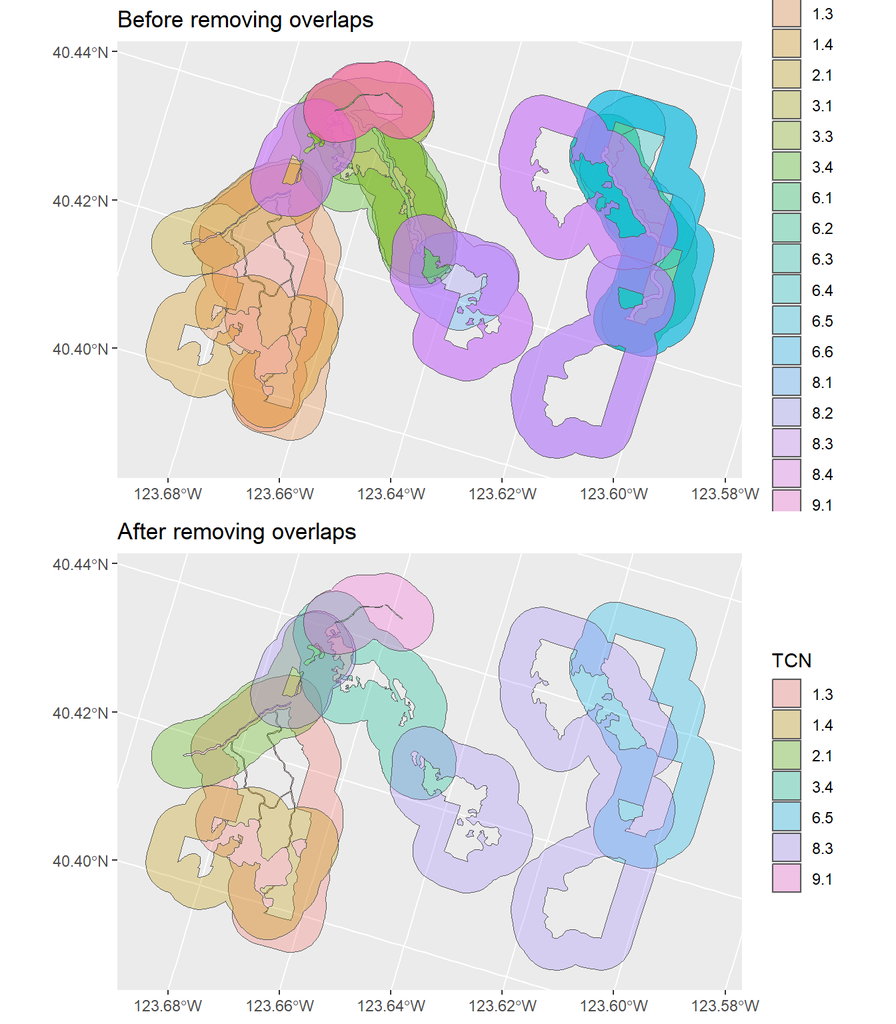

```r
grid.arrange(impact_map_full,impact_map_filtered, nrow = 2)
```

#### Identify PM treatments that need impact area calculations

```r
PM_TCNs <- combined_shp %>%
  filter(Tobj =="Pest_Management") %>%
  select(TCN) %>%
  st_drop_geometry() %>%
  unlist()
```

```r
impact_list <- c(buff_combined$TCN, PM_TCNs)
```

```r
buffers_final <- buff_combined <- buffers |> bind_rows() %>%
  filter(TCN %in% impact_list)
```

## The TCNs that will have impact area calculations are 1.3, 1.4, 2.1, 3.4, 6.5, 8.3, 9.1

## Intersect the impact area polygons with TreeMap

```r
for(i in 1:nrow(buffers_final)){
  shp_buff_sf <- buffers_final[i,]
  shp_buff_sf <- st_transform(shp_buff_sf, crs(tmrast))
  shp_buff <- vect(shp_buff_sf )
  tm_poly_buff <- crop(tmrast, shp_buff, mask = T) %>%
    as.polygons()

  # Intersect
  intersected_sf_buff <- terra::intersect(tm_poly_buff, shp_buff) %>%
    st_as_sf()
    # Remove columns
  intersected_sf_buff  <- intersected_sf_buff  %>%
    select(TM_ID, FVSVariant) # SAVE THIS FOR EACH TREATMENT
  # Calculate areas
  intersected_buff  <- intersected_sf_buff  %>%
    mutate(area_m = as.numeric(st_area(intersected_sf_buff ))) %>%
    mutate(area_ac = area_m/4046.8726098743) %>%
    st_drop_geometry()
    # Write results to table and to shapefile
  file_name <- paste(output_dir, "/", "IA_areas_", project_ID, "_", shp_buff_sf$TCN, ".xlsx", sep = "")
  write_xlsx(intersected_buff, file_name)
  print(paste("Created TreeMap Polygons for impact area of TCN", shp_buff_sf$TCN))

  shp_name <- paste("intersected_IA",  project_ID, shp_buff_sf$TCN, sep = "_")
  shp_name <- gsub("\\.", "_", shp_name)
  st_write(intersected_sf_buff, triaads_output_dir, shp_name, driver = "ESRI Shapefile", delete_layer = T, quiet = T)

}
```

```
[1] "Created TreeMap Polygons for impact area of TCN 1.3"
[1] "Created TreeMap Polygons for impact area of TCN 1.4"
[1] "Created TreeMap Polygons for impact area of TCN 2.1"
[1] "Created TreeMap Polygons for impact area of TCN 3.4"
[1] "Created TreeMap Polygons for impact area of TCN 6.5"
[1] "Created TreeMap Polygons for impact area of TCN 8.3"
[1] "Created TreeMap Polygons for impact area of TCN 9.1"
```

### Map for one impact area to check – remove this to speed up the script

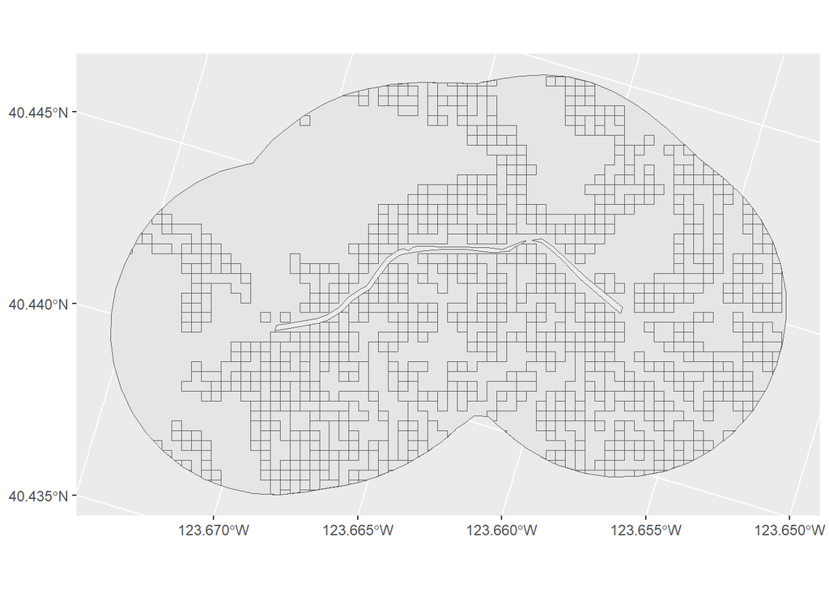

```r
ggplot(shp_buff_sf)+
  geom_sf()+
  geom_sf(data = intersected_sf_buff)
```

# Loop the areas calculations across all shapefiles in a path

For each shapefile in `trt_dir`, calculate the area of each value of TM_ID that intersects with that polygon and save as an excel file

```r
map_list <- list()
treemap_areas_list <- list()
shp_areas_list <- list()
TCN_list <- list()
for (i in 1:length(shp_list)) {
  print(i)
  shp_sf <- shp_list[[i]]
  shp <- vect(shp_sf)
  base_name <- tools::file_path_sans_ext(basename(shapefiles[i]))

  if(!is.null("noFVS") & unique(shp_sf$TCN) %in% noFVS){
    print(paste("Skipping TCN =", shp_sf$TCN))
    next
  }

  tm_poly <- crop(tmrast, shp, mask = T) %>%
    as.polygons %>%
    makeValid()
  # Intersect
  intersected <- terra::intersect(tm_poly, shp)
  print(paste("Created TreeMap Polygons for trt area of TCN", unique(shp_sf$TCN)))

  # convert intersected to sf
  intersected_sf<- sf::st_as_sf(intersected)

  # Remove columns
  intersected_sf <- intersected_sf %>%
    select(TM_ID, FVSVariant) # SAVE THIS FOR EACH TREATMENT

  # Write to shapefile
  shapefile_name <- paste("intersected", project_ID, unique(shp_sf$TCN), sep = "_")
  st_write(intersected_sf, triaads_output_dir, shapefile_name, driver = "ESRI Shapefile", delete_layer = T, quiet = T)

  # Calculate areas
  intersected <- intersected_sf %>%
    mutate(area_m = as.numeric(st_area(intersected_sf))) %>%
    mutate(area_ac = area_m/4046.8726098743) %>%
    st_drop_geometry()
  # Write results to table and to shapefile
  file_name <- paste(output_dir, "/", project_ID, "_", shp_sf$TCN, "_areas.xlsx", sep = "")
  write_xlsx(intersected, file_name)

    # Plot using ggplot2
  map_name <- unique(shp_sf$TCN)
  map <- ggplot() +
    geom_sf(data = intersected_sf,aes(fill = as.factor(TM_ID)), color = NA )+
    labs(fill = "TreeMapper ID (TM_ID)")+
    theme(legend.position = "none")+
    geom_sf(data = shp_sf, fill = NA)

  map_list[[map_name]] <- map

  treemap_areas_list[[base_name]] <- sum(intersected$area_ac)
  shp_areas_list[[base_name]] <- st_area(shp_sf)

  TCN_list[[base_name]] <- shp_sf$TCN

}
```

```
[1] 1
[1] "Created TreeMap Polygons for trt area of TCN 1.1"
[1] 2
[1] "Skipping TCN = 1.2"
[1] 3
[1] "Created TreeMap Polygons for trt area of TCN 1.3"
[1] 4
[1] "Created TreeMap Polygons for trt area of TCN 1.4"
[1] 5
[1] "Skipping TCN = 1.5"
[1] 6
[1] "Skipping TCN = 1.6"
[1] 7
[1] "Created TreeMap Polygons for trt area of TCN 2.1"
[1] 8
```

[output cut: 51 more lines]

# Find TreeMap acres for each polygon as a percentage of total shapefile area

Treemap acres = the acreage of the polygon that excludes non-forested pixels

```r
treemap_areas_df<- tibble(
  Name = names(treemap_areas_list),
  Value = unlist(treemap_areas_list)
)

treemap_areas_df <- treemap_areas_df %>%
  mutate(Value = round(Value)) %>%
  rename("TreeMap Acres" = Value) %>%
  rename(Shapefile = Name)
```

## Sum areas for treatments with multipart polygons

```r
shp_areas_list_sums <- sapply(shp_areas_list, sum)

shp_areas_df <- tibble(
  Name = names(shp_areas_list_sums),
  Value = unlist(shp_areas_list_sums)
)
```

## Do the same for TCN

```r
TCN_list <- sapply(TCN_list, unique)

tcn_df <- tibble(
  Shapefile = names(TCN_list),
  TCN = unlist(TCN_list)
)
```

```r
shp_areas_df <- shp_areas_df %>%
  mutate(Value = Value/4046.86) %>%
  mutate(Value = round(Value)) %>%
  rename("Shapefile Acres" = Value) %>%
  rename(Shapefile = Name)

if(length(tcn_df)>0){
 shp_areas_df <- full_join(tcn_df, shp_areas_df)
}
areas_table <- full_join(shp_areas_df, treemap_areas_df) %>%
  mutate(Percentage = round(`TreeMap Acres`/`Shapefile Acres`*100, 1)) %>%
  arrange(TCN)
# Print a pretty table
flextable(areas_table)
```

| Shapefile | TCN | Shapefile Acres | TreeMap Acres | Percentage |
| --- | --- | --- | --- | --- |
| 71399131_1_1_20250110_region | 1.1 | 35 | 22 | 62.9 |
| 71399131_1_3_20250110_region | 1.3 | 550 | 518 | 94.2 |
| 71399131_1_4_20250110_region | 1.4 | 215 | 196 | 91.2 |
| 71399131_2_1_20250110_region | 2.1 | 13 | 2 | 15.4 |
| 71399131_3_1_20250110_region | 3.1 | 94 | 83 | 88.3 |
| 71399131_3_3_20250110_region | 3.3 | 106 | 104 | 98.1 |
| 71399131_3_4_20250110_region | 3.4 | 117 | 102 | 87.2 |
| 71399131_6_1_20250110_region | 6.1 | 55 | 19 | 34.5 |
| 71399131_6_2_20250110_region | 6.2 | 55 | 19 | 34.5 |
| 71399131_6_3_20250110_region | 6.3 | 299 | 277 | 92.6 |
| 71399131_6_4_20250110_region | 6.4 | 46 | 41 | 89.1 |
| 71399131_6_5_20250110_region | 6.5 | 400 | 337 | 84.2 |
| 71399131_6_6_20250110_region | 6.6 | 400 | 337 | 84.2 |
| 71399131_7_1_20250110_region | 7.1 | 299 | 277 | 92.6 |
| 71399131_8_1_20250110_region | 8.1 | 345 | 328 | 95.1 |
| 71399131_8_2_20250110_region | 8.2 | 487 | 383 | 78.6 |
| 71399131_8_3_20250110_region | 8.3 | 831 | 710 | 85.4 |
| 71399131_8_4_20250110_region | 8.4 | 831 | 710 | 85.4 |
| 71399131_9_1_20250110_region | 9.1 | 4 | 0 | 0.0 |
| 71399131_9_2_20250110_region | 9.2 | 4 | 0 | 0.0 |
| 71399131_9_3_20250110_region | 9.3 | 4 | 0 | 0.0 |

# Maps & Overlaps

### Plot all treatments together and highlight overlaps

```r
# Find overlapping areas
overlaps <- st_intersection(combined_shp) %>%
  filter(n.overlaps > 1) %>%  # Keep only actual overlaps
  mutate(Name = "Overlap")
```

```
geometry errors: 3
```

```r
plot_data <- bind_rows(combined_shp, overlaps)
```

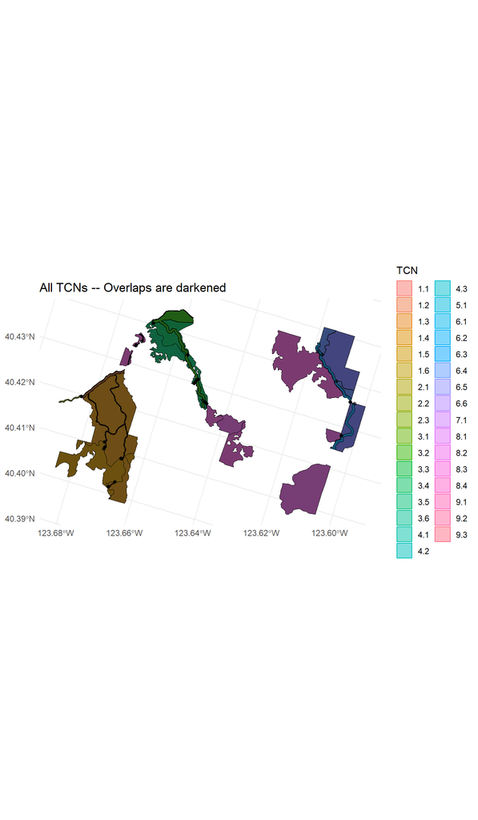

```r
if(length(tcn_df)>0){
  ggplot() +
    geom_sf(data = combined_shp, aes(fill = as.factor(TCN), col = as.factor(TCN)), alpha = 0.5) +
    geom_sf(data = overlaps, fill = "black", color = "black", alpha = 0.5) +
    theme_minimal() +
    labs(title = "All TCNs -- Overlaps are darkened",
         fill = "TCN",
         col = "TCN")
}
```

### Plot each treatment separately, except when there are identical geometries

```r
map_dupes <- combined_shp %>%
  group_by(geometry) %>% summarize(TCNs = paste(TCN, collapse = ", ")) %>%
  st_drop_geometry()
```

If multiple TCNs are listed, it means that the maps for those TCNs look identical

```
[1] "MAP FOR 8.3, 8.4"
$`8.3`
```

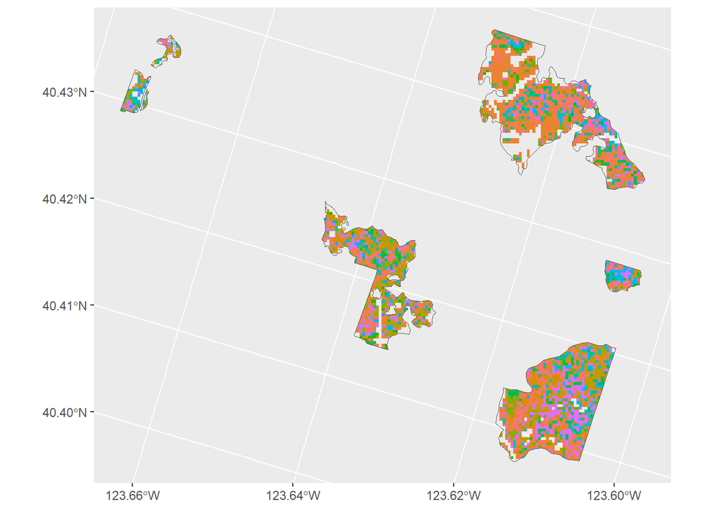

```
[1] "MAP FOR 1.5, 1.6"
$<NA>
NULL

[1] "MAP FOR 1.3"
$`1.3`
```

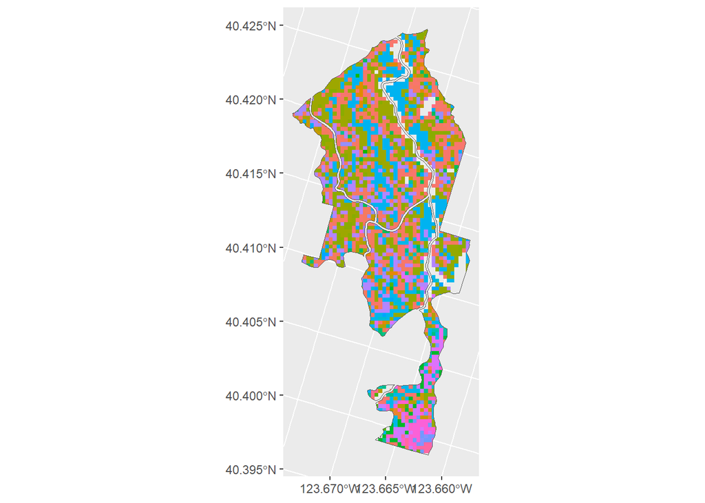

```
[1] "MAP FOR 8.2"
$`8.2`
```

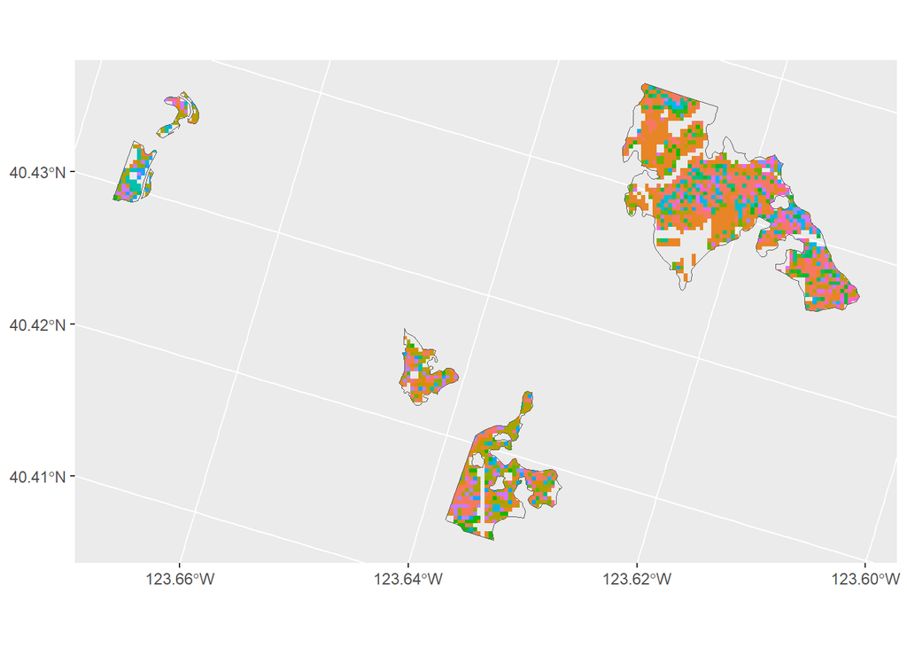

```
[1] "MAP FOR 4.1, 4.2, 4.3, 5.1, 6.5, 6.6"
$<NA>
NULL

[1] "MAP FOR 8.1"
$`8.1`
```

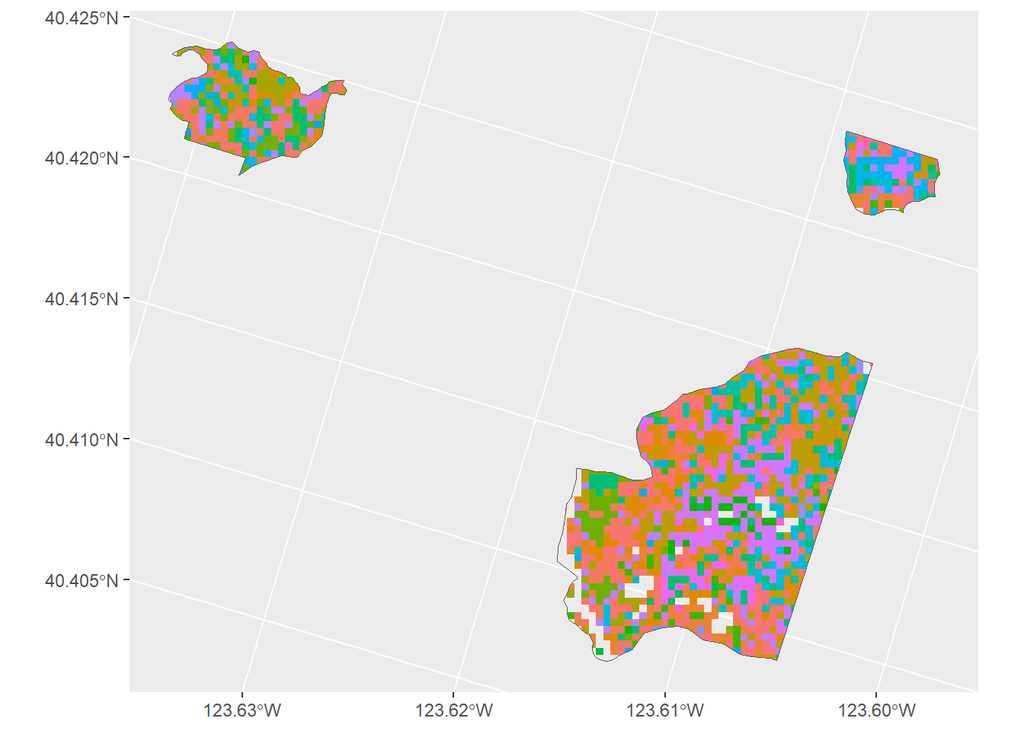

```
[1] "MAP FOR 3.5, 3.6"
$<NA>
NULL

[1] "MAP FOR 6.3, 7.1"
$`6.3`
```

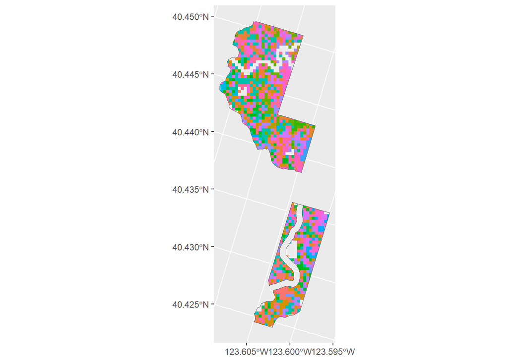

```
[1] "MAP FOR 1.4"
$`1.4`
```

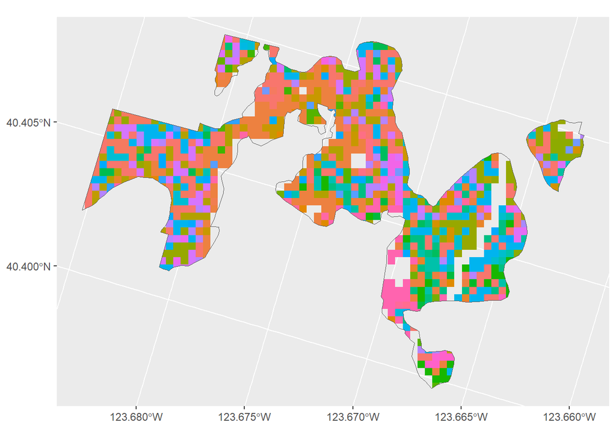

```
[1] "MAP FOR 3.4"
$`3.4`
```

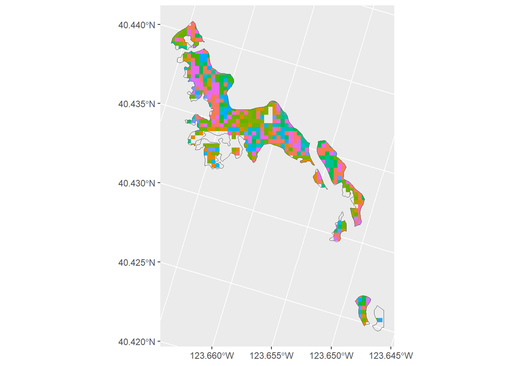

```
[1] "MAP FOR 3.3"
$`3.3`
```

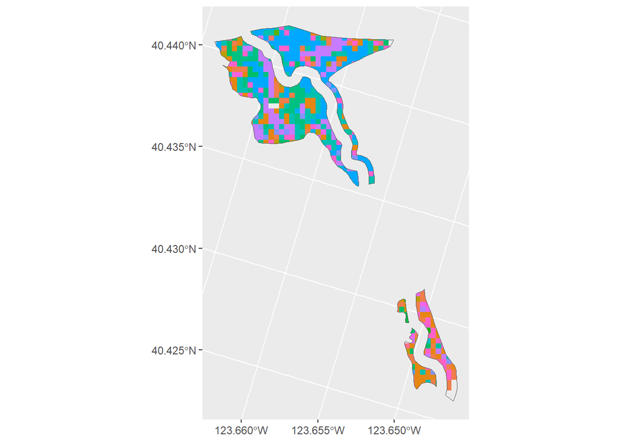

```
[1] "MAP FOR 3.1, 3.2"
$`3.1`
```

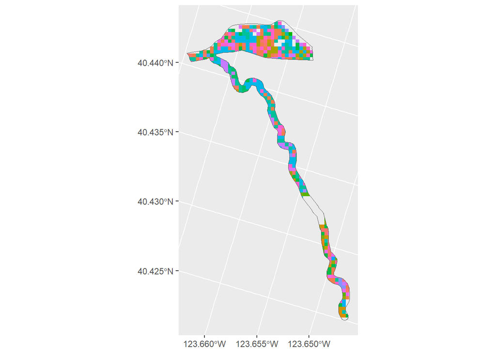

```
[1] "MAP FOR 6.1, 6.2"
$`6.1`
```

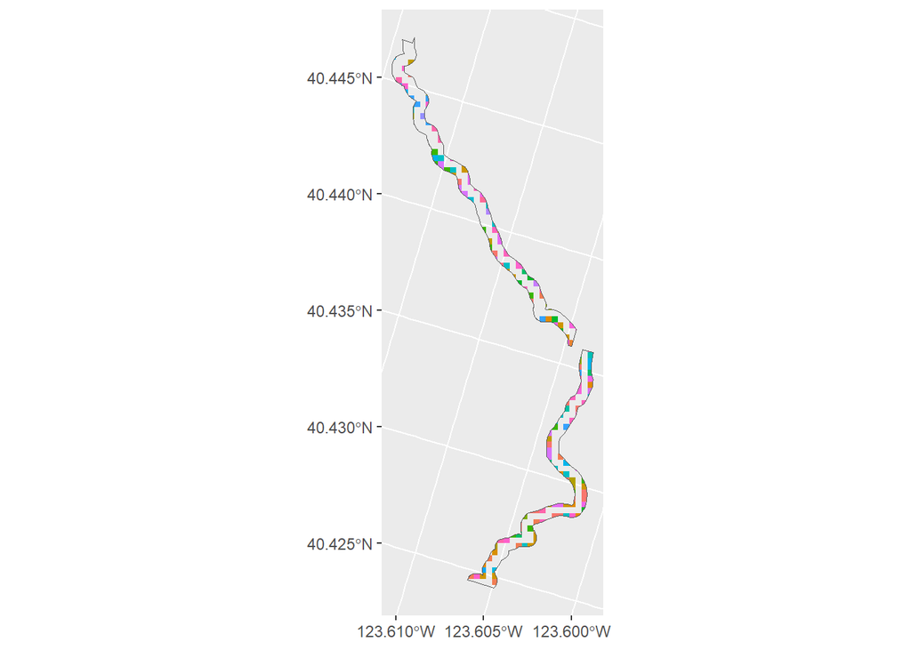

```
[1] "MAP FOR 6.4"
$`6.4`
```

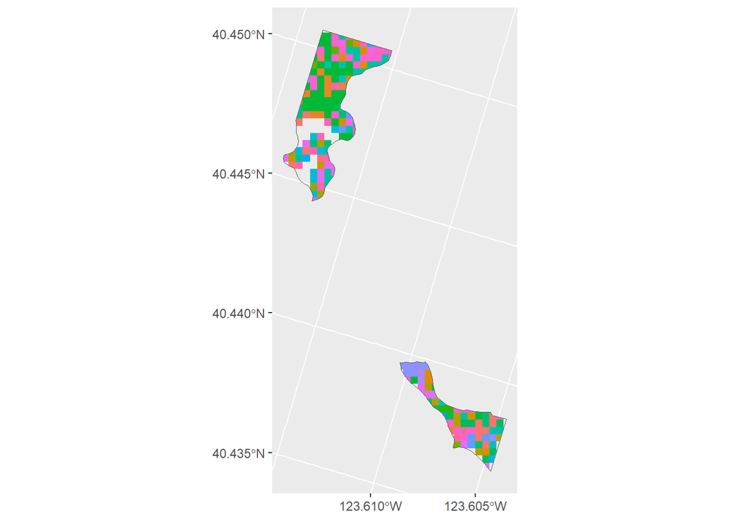

```
[1] "MAP FOR 1.1, 1.2"
$`1.1`
```

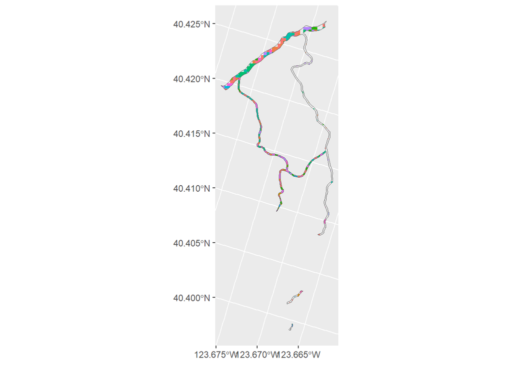

```
[1] "MAP FOR 2.1, 2.2, 2.3"
$`2.1`
```

[2 more figures not shown]

```r
for(i in 1:nrow(map_dupes)){
  TCNs_i <- map_dupes[i, "TCNs"] %>% unlist()
  first_TCN <- strsplit(TCNs_i, ",")[[1]][1]
  print(paste("MAP FOR", TCNs_i))
  print(map_list[first_TCN])
}
```

### Identify overlapping pairs

```r
# Create a pairwise intersection matrix
overlap_list <- st_intersects(combined_shp, sparse = F)
rownames(overlap_list) <- combined_shp$TCN
colnames(overlap_list) <- combined_shp$TCN
diag(overlap_list) <- FALSE

# Find positions of FALSE values
true_positions <- which(overlap_list == TRUE, arr.ind = TRUE)

# Add row and column names
result <- data.frame(
  Row = rownames(overlap_list)[true_positions[, 1]],
  Column = colnames(overlap_list)[true_positions[, 2]]
)

# Create a consistent ordering for each pair
result$pair_id <- apply(result, 1, function(x) paste(sort(x), collapse = "/"))
# Keep only unique pairs
if(nrow(result)>0){
  unique_df <- result[!duplicated(result$pair_id), c("Row", "Column")]
  for(i in 1:nrow(unique_df)){
    #print(paste(unique_df[i, 1], "overlaps with", unique_df[i, 2]))
  }
}
```

```r
# Find overlapping areas
overlaps <- st_intersection(combined_shp) %>%
  filter(n.overlaps > 1) %>%  # Keep only actual overlaps
  mutate(Name = "Overlap")
```

```
geometry errors: 3
```

### Plot each treatment group (e.g. 1.1 and 1.2) together, with overlaps

```r
if(length(tcn_df)>0){
  combined_shp$treatment_group <- sub("\\..*", "", combined_shp$TCN)
  overlaps$treatment_group <- sub("\\..*", "", overlaps$TCN)
}
```

```
[1] "Treatment_group_8"
```

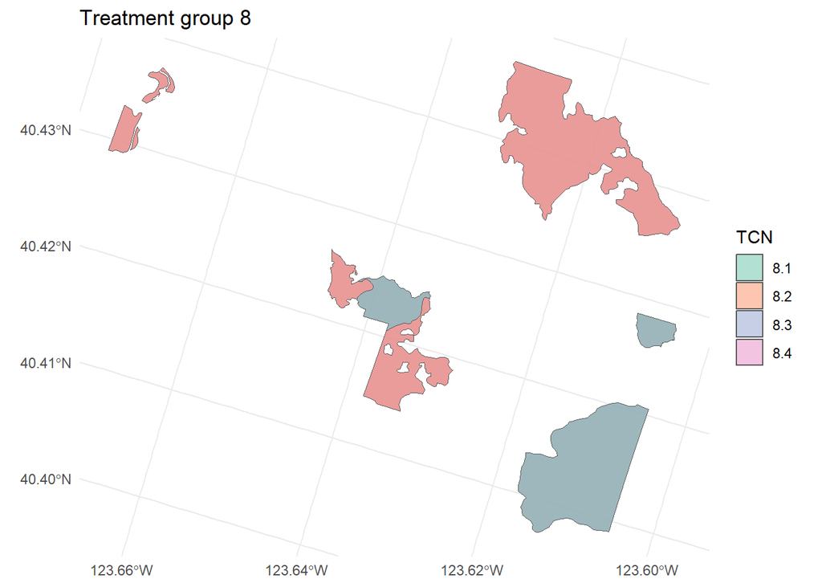

```
[1] "Treatment_group_1"
```

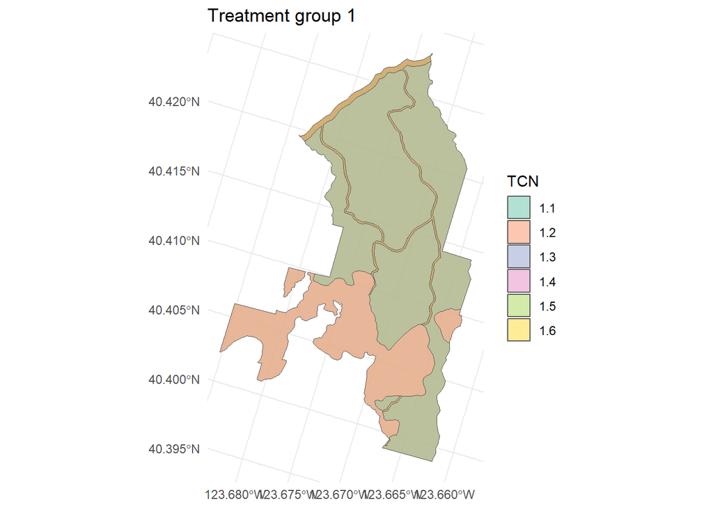

```
[1] "Treatment_group_4"
```

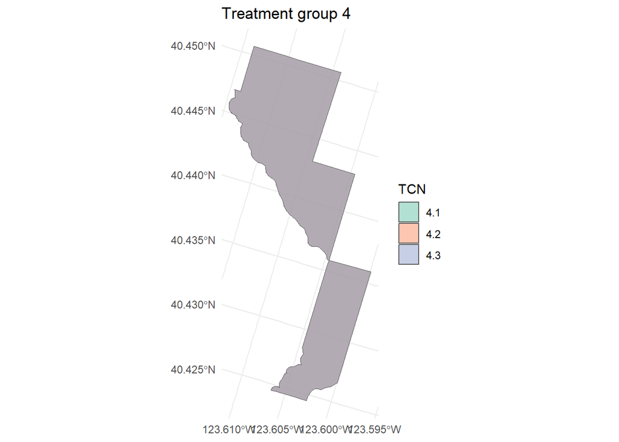

```
[1] "Treatment_group_5"
```

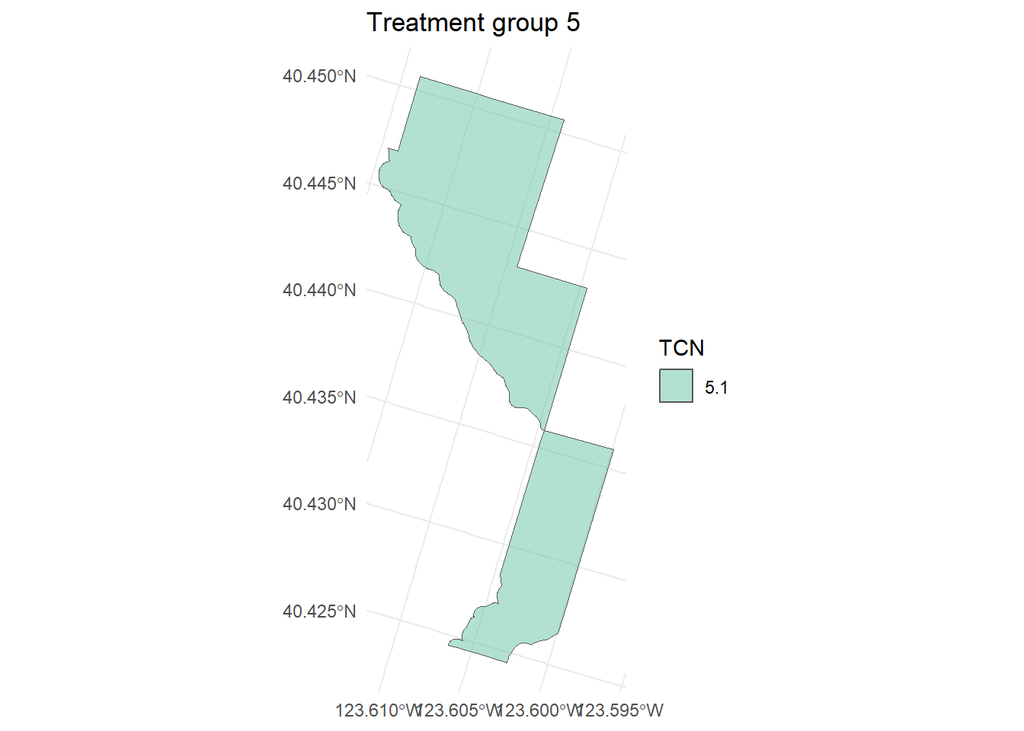

```
[1] "Treatment_group_6"
```

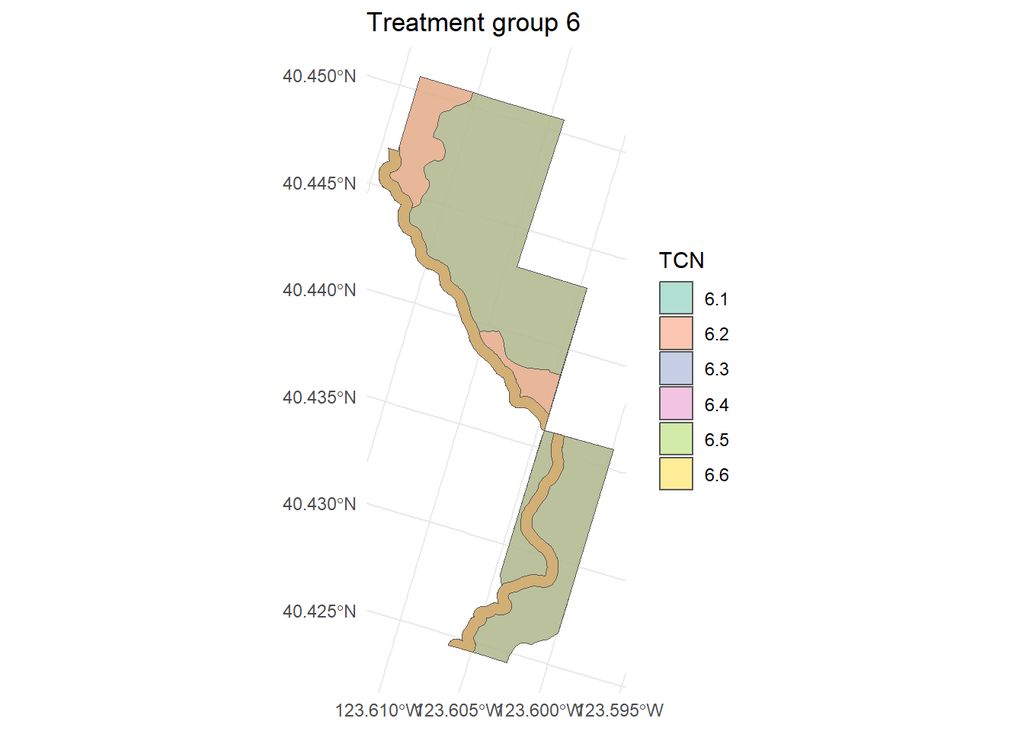

```
[1] "Treatment_group_3"
```

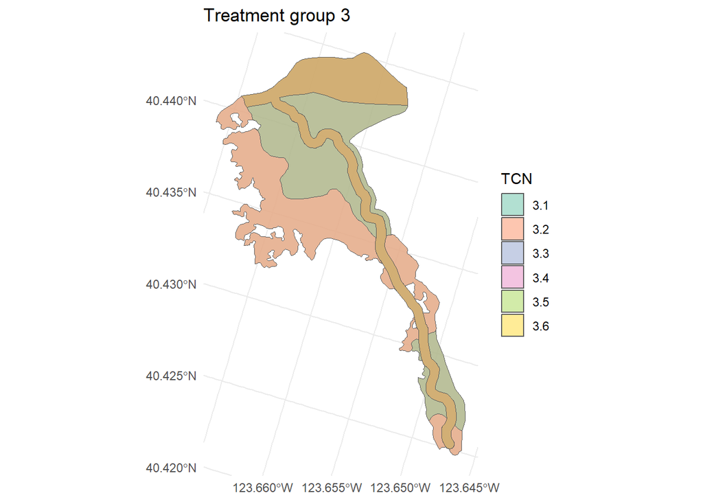

```
[1] "Treatment_group_7"
```

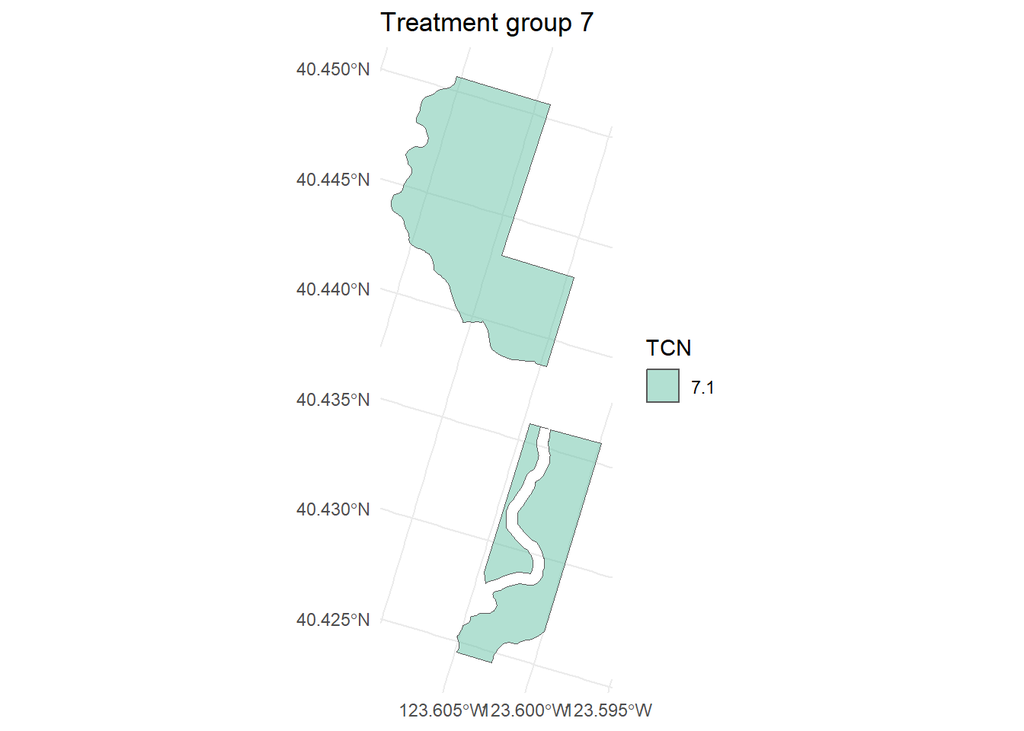

```
[1] "Treatment_group_2"
```

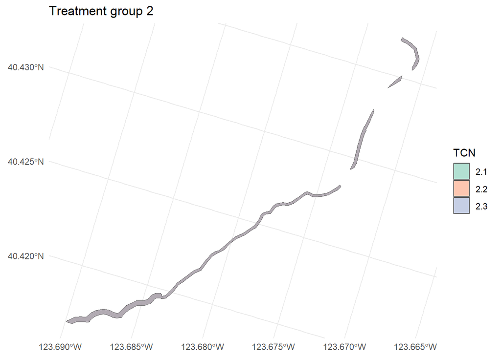

```
[1] "Treatment_group_9"
```

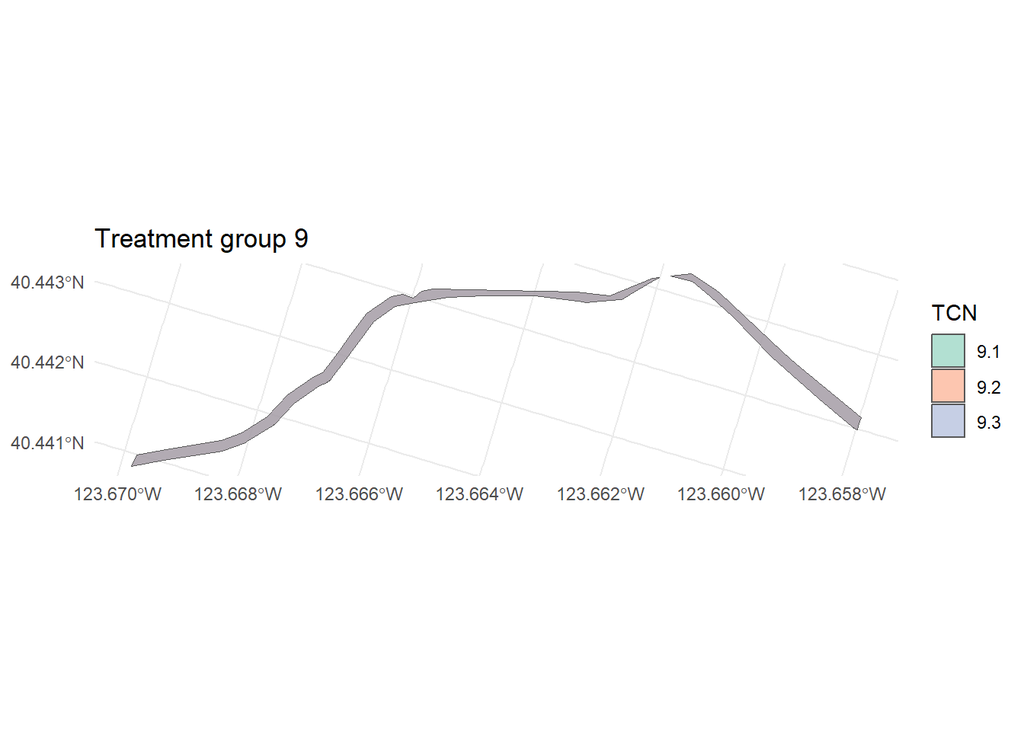

```r
treatment_groups <- unique(combined_shp$treatment_group)
map_list2 <- list()
for(i in treatment_groups){
  combined_i <- combined_shp %>%
    filter(treatment_group==i)
  overlaps_i <- overlaps %>%
    filter(treatment_group == i)

  combined_i <- combined_i %>%
    mutate(area = st_area(geometry)) %>%
    arrange(desc(area))  # Largest first

  map <- ggplot() +
    geom_sf(data = combined_i, aes(fill = as.factor(TCN)), alpha = 0.5) +
    scale_fill_brewer(palette = "Set2") +
    theme_minimal() +
    labs(title = paste0("Treatment group ", i),
         fill = "TCN",
         col = "TCN")
  map_name <- paste("Treatment_group", i, sep = "_")
  map_list2[[map_name]] <- map
}
for (i in seq_along(map_list2)) {
  print(names(map_list2)[i])
  print(map_list2[[i]])
}
```

## Plot the project in California to check FVS variant selection

```r
ca <- st_read(file.path(ca_dir, "CA_State_TIGER2016_5070.shp"))
```

```r
fvs_varloc <- st_as_sf(fvs_varloc) %>%
  filter(FVSVariant %in% c("WS", "NC", "CA", "SO")) %>%
  group_by(FVSVariant) |>
  summarise(geometry = st_union(geometry), .groups = "drop")
```

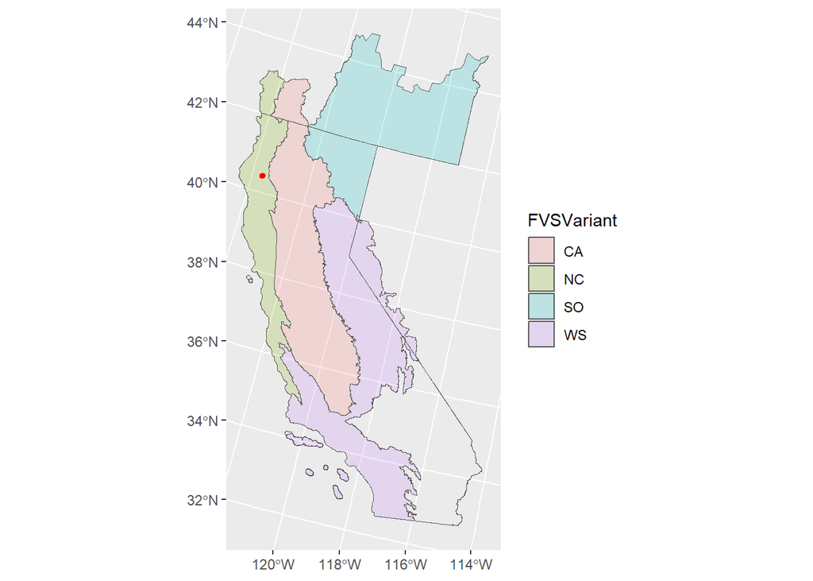

```r
centroids <- st_centroid(combined_shp %>% st_zm())
circle_buffer <- st_buffer(centroids, dist = 5000)

ggplot() +
      geom_sf(data = fvs_varloc,  aes(fill = FVSVariant), alpha = 0.2)+
    geom_sf(data = ca, fill = NA)+
  geom_sf(data = circle_buffer, col = "red", fill = "red")
```

```r
print(paste("FVS Variant selection is/are:"))
```

```
[1] "FVS Variant selection is/are:"
```

```r
unique(combined_shp$FVSVariant)
```

```
[1] "NC"
```